# Cox model case study

R

Survival analysis

Published

July, 2024

Analyzing prostate cancer dataset using a Cox model. The primary goal is to discover patterns in survival, and to do an analysis of covariance to assess the effect of treatment while adjusting for patient heterogeneity. Prediction is a secondary goal.

# Data

We consider the 506-patient prostate cancer dataset from Byar and Green. These data were from a randomized trial comparing four treatments for stage 3 and 4 prostate cancer, with almost equal numbers of patients on placebo and each of three doses of estrogen. Four patients had missing values on all of the following variables: wt, pf, hx, sbp, dbp, ekg, hg, bm; two of these patients were also missing sz. These patients are excluded from consideration.

We will follow guidelines given in the book Regression Modeling Strategies by Frank Harrell and his general approach to this dataset in Chapter 21. The analysis is expanded compared to what was done in the book.

There are 354 deaths among the 502 patients and we will use a multivariate survival model to explain the time until death (of any cause).

## Loading data

```r
library(Hmisc)
library(survival)
library(rms)
library(scales)
library(ggplot2)
library(latex2exp)
library(knitr)
library(kableExtra)
library(modelsummary)
getHdata(prostate)
```

We start by showing summary of all the variables in the dataset

**Click here to see output**

Preprocess data for function `datasummary_skim`.

```r
prostate_summary <- prostate

# Convert 'labelled' columns to numeric
prostate_summary[] <- lapply(prostate_summary, function(x) {
  if (inherits(x, "labelled")) {
    as.numeric(x)
  } else {
    x
  }
})

prostate_summary$bm <- as.factor(prostate$bm)
prostate_summary$stage <- as.factor(prostate$stage)
prostate_summary$hx <- as.factor(prostate$hx)

prostate_summary <- prostate_summary[
  ,
  !names(prostate) %in% c("patno", "sdate")
]

factors <- sapply(prostate_summary, is.factor)
```

Summary of factor variables in data

```r
datasummary_skim(prostate_summary[factors])
```

|  |  | N | % |
| --- | --- | --- | --- |
| stage | 3 | 289 | 57.6 |
|  | 4 | 213 | 42.4 |
| rx | placebo | 127 | 25.3 |
|  | 0.2 mg estrogen | 124 | 24.7 |
|  | 1.0 mg estrogen | 126 | 25.1 |
|  | 5.0 mg estrogen | 125 | 24.9 |
| status | alive | 148 | 29.5 |
|  | dead - prostatic ca | 130 | 25.9 |
|  | dead - heart or vascular | 96 | 19.1 |
|  | dead - cerebrovascular | 31 | 6.2 |
|  | dead - pulmonary embolus | 14 | 2.8 |
|  | dead - other ca | 25 | 5.0 |
|  | dead - respiratory disease | 16 | 3.2 |
|  | dead - other specific non-ca | 28 | 5.6 |
|  | dead - unspecified non-ca | 7 | 1.4 |
|  | dead - unknown cause | 7 | 1.4 |
| pf | normal activity | 450 | 89.6 |
|  | in bed < 50% daytime | 37 | 7.4 |
|  | in bed > 50% daytime | 13 | 2.6 |
|  | confined to bed | 2 | 0.4 |
| hx | 0 | 289 | 57.6 |
|  | 1 | 213 | 42.4 |
| ekg | normal | 168 | 33.5 |
|  | benign | 23 | 4.6 |
|  | rhythmic disturb & electrolyte ch | 51 | 10.2 |
|  | heart block or conduction def | 26 | 5.2 |
|  | heart strain | 150 | 29.9 |
|  | old MI | 75 | 14.9 |
|  | recent MI | 1 | 0.2 |
| bm | 0 | 420 | 83.7 |
|  | 1 | 82 | 16.3 |

Summary of continuous variables in data

Unique

Missing Pct.

Mean

SD

Min

Median

Max

Histogram

dtime

76

0

36.1

23.3

0.0

34.0

76.0

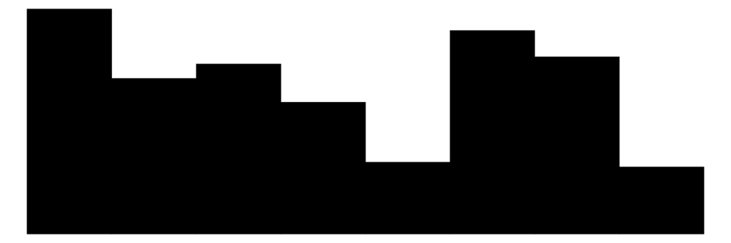

age

42

0

71.5

7.1

48.0

73.0

89.0

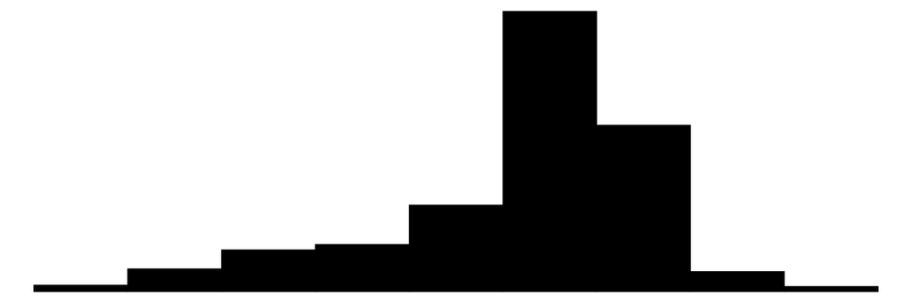

wt

68

0

99.0

13.4

69.0

98.0

152.0

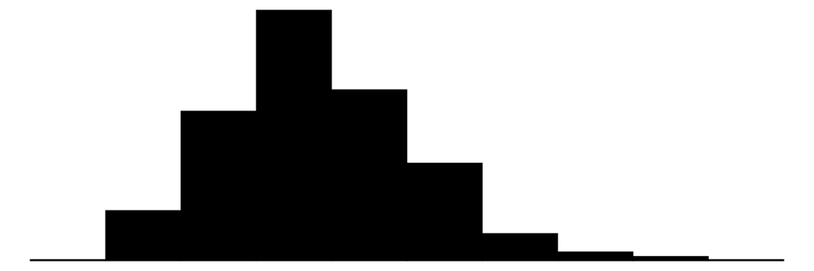

sbp

18

0

14.4

2.4

8.0

14.0

30.0

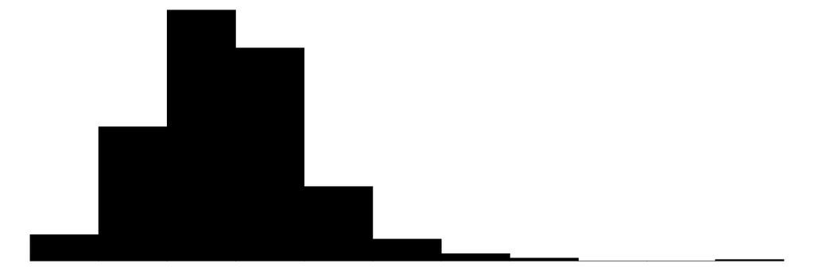

dbp

12

0

8.1

1.5

4.0

8.0

18.0

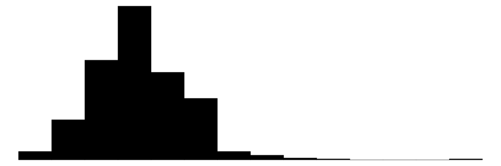

hg

91

0

13.4

2.0

5.9

13.7

21.2

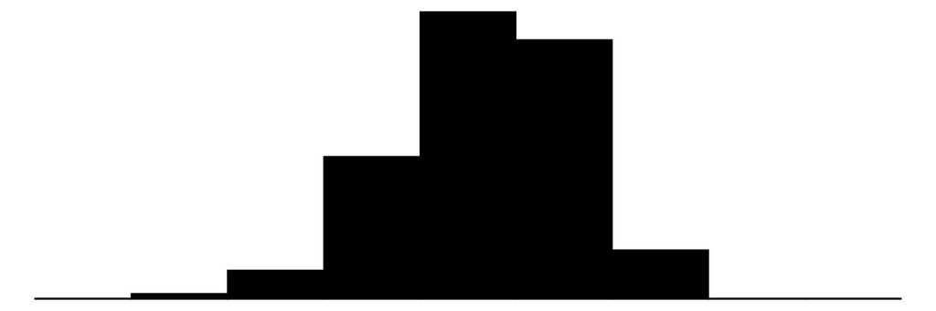

sz

56

1

14.6

12.3

0.0

11.0

69.0

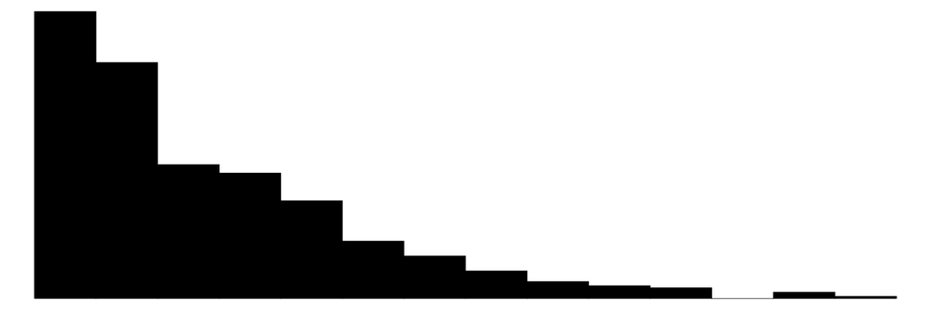

sg

12

2

10.3

2.0

5.0

10.0

15.0

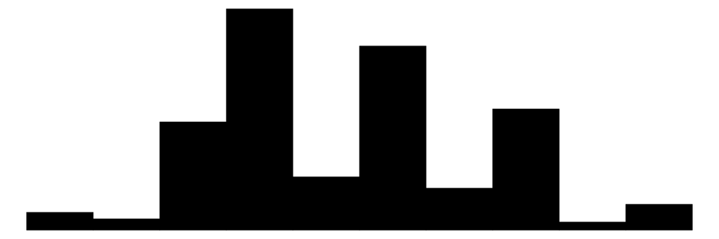

ap

128

0

12.2

62.2

0.1

0.7

999.9

[figure not shown]

```r
datasummary_skim(prostate_summary[!factors])
```

We see that the variable ekg only has one observation in the last category and pf has two. So, we combine recent MI with old MI and call it MI, and we combine confined to bed with $>50\%$ daytime.

```r
levels(prostate$ekg)[levels(prostate$ekg) %in% c("old MI", "recent MI")] <- "MI"

levels(prostate$pf) <- c(
  levels(prostate$pf)[1:3],
  levels(prostate$pf)[3]
)
```

## Imputing missing values

We have 27 patients with missing values as seen below, so we do imputation on these.

The proportion of missing values is $0.05$, so we just do single imputation, since simpler to make plots and validation. However if the proportion were higher one should do multiple imputation.

```r
sum(is.na(prostate))
```

```
[1] 27
```

```r
colSums(is.na(prostate))
```

```
 patno  stage     rx  dtime status    age     wt     pf     hx    sbp    dbp
     0      0      0      0      0      1      2      0      0      0      0
   ekg     hg     sz     sg     ap     bm  sdate
     8      0      5     11      0      0      0
```

```r
w <- transcan(
  ~ sz + sg + ap + sbp + dbp + age +
    wt + hg + ekg + pf + bm + hx,
  imputed = TRUE,
  data = prostate, pl = FALSE, pr = FALSE
)

attach(prostate)
sz <- impute(w, sz, data = prostate)
sg <- impute(w, sg, data = prostate)
age <- impute(w, age, data = prostate)
wt <- impute(w, wt, data = prostate)
kg <- impute(w, ekg, data = prostate)
```

# Specifying the model

A Cox proportional hazards model is in terms of the hazard function given by:
$$\lambda(t\vert X)=\lambda(t)\exp(X\beta).$$
We fit a Cox proportional hazards model with the predictors and their degrees of freedom specified in the table below. All continuous predictors will be modeled with a restricted cubic spline with 4 knots.

| Predictor | Name | d.f. | Levels |
| --- | --- | --- | --- |
| Dose of estrogen | rx | 3 | placebo, 0.2, 1.0, 5.0 mg estrogen |
| Age in years | age | 3 |  |
| Weight index | wt | 3 |  |
| Performance rating | pf | 2 | normal, in bed < 50% of time, in bed > 50% |
| History of cardiovascular disease | hx | 1 | present/absent |
| Systolic blood pressure/10 | sbp | 3 |  |
| Diastolic blood pressure/10 | dbp | 3 |  |
| Electrocardiogram code | ekg | 5 | normal, benign, rhythm disturb., block, strain, myocardial infarction |
| Serum hemoglobin (g/100ml) | hg | 3 |  |
| Tumor size (cm^2) | sz | 3 |  |
| Stage/histologic grade combination | sg | 3 |  |
| Serum prostatic acid phosphatase | ap | 3 |  |
| Bone metastasis | bm | 1 | present/absent |

We see that we have 36 degrees of freedom in our model, so about 1/10 of the amount of deaths there are. So there is some hope our model will validate.

```r
dd <- datadist(prostate)
options(datadist = "dd")
units(prostate$dtime) <- "Month"
s <- Surv(prostate$dtime, prostate$status != "alive")

f <- cph(s ~ rx + rcs(age, 4) + rcs(wt, 4) + pf + hx +
           rcs(sbp, 4) + rcs(dbp, 4) + ekg + rcs(hg, 4) +
           rcs(sg, 4) + rcs(sz, 4) + rcs(log(ap), 4) + bm, data = prostate)
print(f, html = TRUE, coefs = FALSE)
```

```
Frequencies of Missing Values Due to Each Variable
  s  rx age  wt  pf  hx sbp dbp ekg  hg  sg  sz  ap  bm
  0   0   1   2   0   0   0   0   8   0  11   5   0   0

Cox Proportional Hazards Model

cph(formula = s ~ rx + rcs(age, 4) + rcs(wt, 4) + pf + hx + rcs(sbp,
    4) + rcs(dbp, 4) + ekg + rcs(hg, 4) + rcs(sg, 4) + rcs(sz,
    4) + rcs(log(ap), 4) + bm, data = prostate)

                        Model Tests     Discrimination
                                               Indexes
Obs        475    LR chi2    136.31     R2       0.250
Events     338    d.f.           36    R2(36,475)0.190
Center -1.9598    Pr(> chi2) 0.0000    R2(36,338)0.257
                  Score chi2 145.22     Dxy      0.344
                  Pr(> chi2) 0.0000
```

## Data reduction using domain knowledge

We do the following changes

- Combine systolic blood pressure (sbp) and diastolic blood pressure (dbp) into Mean Arterial Pressure.
- Combine history of cardiovascular disease (hx) and electrocardiogram code ekg and assume linear. We code it as 2 if ekg are not normal or benign and hx, 1 if either, and 0 if none.
- Weight index not that important, so only use 3 knots.
- Take log of Serum prostatic acid phosphatase (ap) for numeric stability (heavy right-tail) and allow 1 more knot for compensation
- The tumor variables tumor size (sz) and stage/histologic grade combination (sg) should be important variables, but since we have both we keep them but give them only 3 knots each.
- Assume performance rating (pf) is linear.

```r
prostate$map <- (2 * prostate$dbp + prostate$sbp) / 3
label(prostate$map) <- "Mean Arterial Pressure/10"

prostate$heart_d <- prostate$hx + prostate$ekg %nin% c("normal", "benign")
label(prostate$heart_d) <- "Heart Disease Code"

prostate$pf_linear <- as.numeric(prostate$pf)
```

```r
dd <- datadist(prostate)
options(datadist = "dd")

f <- cph(
  s ~ rx + rcs(age, 4) + rcs(wt, 3) + pf_linear + heart_d + rcs(map, 3)
  + rcs(hg, 4) + rcs(sg, 3) + rcs(sz, 3) + rcs(log(ap), 5) + bm,
  x = TRUE, y = TRUE, surv = TRUE, time.inc = 5 * 12, data = prostate
)

print(f, html = TRUE, coefs = 3)
```

```
Frequencies of Missing Values Due to Each Variable
        s        rx       age        wt pf_linear   heart_d       map        hg
        0         0         1         2         0         0         0         0
       sg        sz        ap        bm
       11         5         0         0

Cox Proportional Hazards Model

cph(formula = s ~ rx + rcs(age, 4) + rcs(wt, 3) + pf_linear +
    heart_d + rcs(map, 3) + rcs(hg, 4) + rcs(sg, 3) + rcs(sz,
    3) + rcs(log(ap), 5) + bm, data = prostate, x = TRUE, y = TRUE,
    surv = TRUE, time.inc = 5 * 12)

                        Model Tests     Discrimination
                                               Indexes
Obs        483    LR chi2    118.48     R2       0.218
Events     344    d.f.           24    R2(24,483)0.178
Center -2.2006    Pr(> chi2) 0.0000    R2(24,344)0.240
                  Score chi2 125.95     Dxy      0.323
                  Pr(> chi2) 0.0000

                   Coef    S.E.    Wald Z Pr(>|Z|)
rx=0.2 mg estrogen -0.0131  0.1518 -0.09  0.9314
rx=1.0 mg estrogen -0.3867  0.1675 -2.31  0.0210
rx=5.0 mg estrogen -0.0916  0.1595 -0.57  0.5656
. . .
```

```r
anova(f, html = TRUE)
```

```
                Wald Statistics          Response: s

 Factor          Chi-Square d.f. P
 rx                6.61      3   0.0856
 age              12.30      3   0.0064
  Nonlinear        7.69      2   0.0214
 wt                8.48      2   0.0144
  Nonlinear        3.39      1   0.0655
 pf_linear         3.27      1   0.0706
 heart_d          23.90      1   <.0001
 map               0.28      2   0.8683
  Nonlinear        0.21      1   0.6479
 hg                8.89      3   0.0308
  Nonlinear        3.95      2   0.1386
 sg                2.39      2   0.3031
  Nonlinear        0.00      1   0.9974
 sz               12.42      2   0.0020
  Nonlinear        0.04      1   0.8443
 ap                6.95      4   0.1388
  Nonlinear        6.77      3   0.0795
 bm                0.17      1   0.6772
 TOTAL NONLINEAR  20.66     11   0.0371
 TOTAL           119.17     24   <.0001
```

## Checking Proportional Hazards

A Cox model should have proportional hazards, since if we look at two individuals with covariate values $\boldsymbol{X}$ and $\boldsymbol{X}^*$ then the ratio of their hazard rates is
$$\frac{h(t \vert \boldsymbol{X})}{h(t \vert \boldsymbol{X}^*)}=\exp\Big[\sum_{k=1}^p \beta_k(X_k-X_{k^*})\Big],$$
which is a constant. We can test this assumption using scaled Schoenfeld residuals separately for each predictor and test the PH assumption using the “correlation with time” test. Smoothed trends in the residuals are also plotted.

```r
z <- predict(f, type = "terms", data = prostate)
f_short <- cph(s ~ z, x = TRUE, y = TRUE, data = prostate)
phtest <- cox.zph(f_short, transform = "identity", terms = FALSE)
phtest
```

```
             chisq df     p
rx        3.63e+00  1 0.057
age       1.63e+00  1 0.201
wt        1.28e-02  1 0.910
pf_linear 1.15e-02  1 0.915
heart_d   3.58e-01  1 0.550
map       1.61e+00  1 0.205
hg        1.18e-01  1 0.731
sg        1.28e-02  1 0.910
sz        2.38e-05  1 0.996
ap        1.41e-01  1 0.707
bm        2.25e-01  1 0.635
GLOBAL    8.89e+00 11 0.632
```

```r
plot(phtest, var = "rx")
```

[figure not shown]

## Describing Effects

We plot how each predictor is related to the log hazard of death with $95\%$-confidence bands.

```r
ggplot(Predict(f),
  sepdiscrete = "vertical", nlevels = 4,
  vnames = "names"
)
```

```
`height` was translated to `width`.
```

[figure not shown]

# Presenting the final model for inference

To present point and interval estimates of predictor effects we draw a hazard ratio chart. Since the ap relationship is so non-monotonic we use a 20:1 hazard ratio for this variable. The others use the default.

```r
plot(summary(f, ap = c(1, 20)), log = TRUE, main = "")
```

[figure not shown]

Finally we will also show a nomogram.

```r
surv <- Survival(f)
surv3 <- function(x) surv(3 * 12, lp = x)
surv5 <- function(x) surv(5 * 12, lp = x)
quan <- Quantile(f)
med <- function(x) quan(lp = x) / 12
ss <- c(.05, .1, .2, .3, .4, .5, .6, .7, .8, .9, .95)
nom <- nomogram(f,
  ap = c(.1, .5, 1, 2, 3, 4, 5, 10, 20, 30, 40),
  fun = list(surv3, surv5, med),
  funlabel = c(
    "3-year Survival", "5-year Survival",
    "Median Survival Time (years)"
  ),
  fun.at = list(ss, ss, c(.5, 1:6))
)
plot(nom, cex.axis = 0.8, cex.var = 0.7, xfrac = .65, lmgp = .35)
```

[figure not shown]

This is interpreted by taking a value for each predictor and seeing how many points each value correspond to. Then the total amount of points can be used to find the probability of for example 5-year survival.

# Model for prediction

For a prediction model one should validate the model. We start by doing that

## Validating the model

We will use bootstrapping for validation. We first validate this model for Somers’ $D_{xy}$ rank correlation between predicted log hazard and observed survival time, and for slope shrinkage. The bootstrap is used (with 1000 resamples) to penalize for possible overfitting.

```r
v <- validate(f, B = 1000)
options(prType = "html")
v
```

| Index | Original Sample | Training Sample | Test Sample | Optimism | Corrected Index | Lower | Upper | Successful Resamples |
| --- | --- | --- | --- | --- | --- | --- | --- | --- |
| *D<sub>xy</sub>* | 0.3234 | 0.3525 | 0.2982 | 0.0544 | 0.269 | 0.2083 | 0.3288 | 1000 |
| *R<sup>2</sup>* | 0.2176 | 0.2571 | 0.1815 | 0.0756 | 0.142 | 0.0694 | 0.2086 | 1000 |
| Slope | 1 | 1 | 0.7828 | 0.2172 | 0.7828 | 0.5856 | 0.987 | 1000 |
| *D* | 0.0303 | 0.037 | 0.0247 | 0.0123 | 0.0181 | 0.0054 | 0.0292 | 1000 |
| *U* | -5e-04 | -5e-04 | 0.0027 | -0.0032 | 0.0027 | -0.0013 | 0.0117 | 1000 |
| *Q* | 0.0308 | 0.0375 | 0.022 | 0.0155 | 0.0153 | -0.0048 | 0.0301 | 1000 |
| *g* | 0.7298 | 0.817 | 0.6377 | 0.1793 | 0.5505 | 0.3728 | 0.7084 | 1000 |

### Validate the model for predicting the probability of surviving five years

We will use the non-shrinked estimates to show that this model will have some overfitting consistent with *regression to the mean*.

```r
cal <- calibrate(f, B = 1000, u = 5 * 12)
```

```
Using Cox survival estimates at 60 Months
Convergence problems.... stopping addition
```

```
Convergence problems.... stopping addition
Convergence problems.... stopping addition
Convergence problems.... stopping addition
Convergence problems.... stopping addition
```

```r
plot(cal, subtitles = FALSE)
```

[figure not shown]

The line nearer the ideal line corresponds to apparent predictive accuracy. The blue curve corresponds to bootstrap-corrected estimates. We clearly see some regression to the mean.

## Final model for prediction

For a better model for prediction one should multiply the coefficients in the model by the shrinkage estimate.

```r
v
```

| Index | Original Sample | Training Sample | Test Sample | Optimism | Corrected Index | Lower | Upper | Successful Resamples |
| --- | --- | --- | --- | --- | --- | --- | --- | --- |
| *D<sub>xy</sub>* | 0.3234 | 0.3525 | 0.2982 | 0.0544 | 0.269 | 0.2083 | 0.3288 | 1000 |
| *R<sup>2</sup>* | 0.2176 | 0.2571 | 0.1815 | 0.0756 | 0.142 | 0.0694 | 0.2086 | 1000 |
| Slope | 1 | 1 | 0.7828 | 0.2172 | 0.7828 | 0.5856 | 0.987 | 1000 |
| *D* | 0.0303 | 0.037 | 0.0247 | 0.0123 | 0.0181 | 0.0054 | 0.0292 | 1000 |
| *U* | -5e-04 | -5e-04 | 0.0027 | -0.0032 | 0.0027 | -0.0013 | 0.0117 | 1000 |
| *Q* | 0.0308 | 0.0375 | 0.022 | 0.0155 | 0.0153 | -0.0048 | 0.0301 | 1000 |
| *g* | 0.7298 | 0.817 | 0.6377 | 0.1793 | 0.5505 | 0.3728 | 0.7084 | 1000 |

**Cox Proportional Hazards Model**

```
cph(formula = s ~ rx + rcs(age, 4) + rcs(wt, 3) + pf_linear +
    heart_d + rcs(map, 3) + rcs(hg, 4) + rcs(sg, 3) + rcs(sz,
    3) + rcs(log(ap), 5) + bm, data = prostate, x = TRUE, y = TRUE,
    surv = TRUE, time.inc = 5 * 12)
```

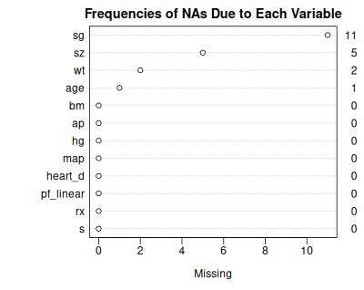

|  | Model Tests | Discrimination Indexes |
| --- | --- | --- |
| Obs 483 | LR χ<sup>2</sup> 118.48 | *R*<sup>2</sup> 0.218 |
| Events 344 | d.f. 24 | *R*<sup>2</sup><sub>24,483</sub> 0.178 |
| Center -2.2006 | Pr(>χ<sup>2</sup>) 0.0000 | *R*<sup>2</sup><sub>24,344</sub> 0.240 |
|  | Score χ<sup>2</sup> 125.95 | *D*<sub>xy</sub> 0.323 |
|  | Pr(>χ<sup>2</sup>) 0.0000 |  |

|  | β | S.E. | Wald *Z* | Pr(>\|*Z*\|) |
| --- | --- | --- | --- | --- |
| rx=0.2 mg estrogen | -0.0102 | 0.1518 | -0.07 | 0.9463 |
| rx=1.0 mg estrogen | -0.3027 | 0.1675 | -1.81 | 0.0707 |
| rx=5.0 mg estrogen | -0.0717 | 0.1595 | -0.45 | 0.6529 |
| … |  |  |  |  |

```r
shrinkage_est <- v[3, 5] # Extract bootstrap estimate of shrinkage
f_prediction <- f
f_prediction$coefficients <- f$coefficients * shrinkage_est

print(f_prediction, html = TRUE, coef = 3)
```

### Approximating the full model

If the client doesn’t want to collect all these variables for prediction we can do model approximation. The goal is to explain `f_prediction`with a trade off between parameters and $R^2$. This can be done by backwards selection.

```r
z <- predict(f_prediction) # compute linear predictor from full model

# Force sigma to be 1 since perfect fit
a <- ols(z ~ rx + rcs(age, 4) + rcs(wt, 3) + pf_linear + heart_d + rcs(map, 3)
         + rcs(hg, 4) + rcs(sg, 3) + rcs(sz, 3)
         + rcs(log(ap), 5) + bm, sigma = 1, data = prostate)

backwards <- fastbw(a, aics = 10000)
print(backwards, html = TRUE, digits = 3)
```

```
 Deleted   Chi-Sq d.f. P      Residual d.f. P      AIC    R2
 map        0.42  2    0.8124   0.42    2   0.8124  -3.58 0.998
 bm         0.22  1    0.6428   0.63    3   0.8894  -5.37 0.997
 sg         3.40  2    0.1826   4.03    5   0.5449  -5.97 0.980
 pf_linear  4.77  1    0.0289   8.81    6   0.1848  -3.19 0.956
 rx        12.93  3    0.0048  21.73    9   0.0098   3.73 0.892
 age       14.73  3    0.0021  36.46   12   0.0003  12.46 0.819
 wt        13.66  2    0.0011  50.12   14   0.0000  22.12 0.751
 ap        20.68  4    0.0004  70.80   18   0.0000  34.80 0.648
 hg        31.13  3    0.0000 101.93   21   0.0000  59.93 0.493
 sz        44.95  2    0.0000 146.88   23   0.0000 100.88 0.269
 heart_d   54.02  1    0.0000 200.90   24   0.0000 152.90 0.000

Approximate Estimates after Deleting Factors

          Coef   S.E.    Wald Z P
[1,] -3.34e-11 0.0455 -7.33e-10 1

Factors in Final Model

None
```

Now the client can choose the trade-off between predictive ability and number of predictors. We visualize this in the following plot

```r
result <- as.data.frame(backwards$result)
total_predictors <- nrow(result)
r_squared <- result$R2
predictors <- c((total_predictors - 1):0)

ggplot(data.frame(predictors, r_squared), aes(x = predictors, y = r_squared)) +
  geom_line(color = "blue") +
  geom_point(color = "red") +
  labs(x = "Predictors", y = TeX("$R^2$")) +
  ggtitle("R-squared vs. Predictors") +
  scale_y_continuous(breaks = pretty_breaks()) +
  theme_minimal()
```

[figure not shown]

A reasonable approach trade off would be to remove map, bm, sg and pf_linear from our model to get an approximate model which still has high $R^2$ of $0.96$ for explaining the full model.

**Linear Regression Model**

```
ols(formula = z ~ rx + rcs(age, 4) + rcs(wt, 3) + heart_d + rcs(hg,
    4) + rcs(sz, 3) + rcs(log(ap), 5), data = prostate, x = TRUE)
```

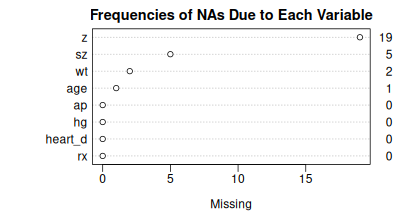

|  | Model Likelihood Ratio Test | Discrimination Indexes |
| --- | --- | --- |
| Obs 483 | LR χ<sup>2</sup> 1510.49 | *R*<sup>2</sup> 0.956 |
| σ 0.1378 | d.f. 18 | *R*<sup>2</sup><sub>adj</sub> 0.954 |
| d.f. 464 | Pr(>χ<sup>2</sup>) 0.0000 | *g* 0.715 |

Residuals

```
     Min       1Q   Median       3Q      Max
-0.44623 -0.08724 -0.02054  0.05327  0.63271
```

|  | β | S.E. | *t* | Pr(>\|*t*\|) |
| --- | --- | --- | --- | --- |
| Intercept | 3.9360 | 0.2263 | 17.39 | <0.0001 |
| rx=0.2 mg estrogen | -0.0030 | 0.0178 | -0.17 | 0.8652 |
| rx=1.0 mg estrogen | -0.4058 | 0.0179 | -22.69 | <0.0001 |
| … |  |  |  |  |

```r
f_approx <- ols(z ~ rx + rcs(age, 4) + rcs(wt, 3) + heart_d
                + rcs(hg, 4) + rcs(sz, 3) + rcs(log(ap), 5)
                , x = TRUE, data = prostate)

print(f_approx, html = TRUE, coefs = 3)
```

# Conclusion

We devolved a Cox proportional hazards model to explain time until death (of any cause) for this dataset. We described the effects the predictors in the model had by various plots.

Throughout we used the guidelines of Regression Modelling Strategies to follow sounds statistical strategies when building and validating a model.